# FIA - NLS Models: Biomass Growth vs. Biomass - Temporally-Balanced, No harvest

## predict and plot

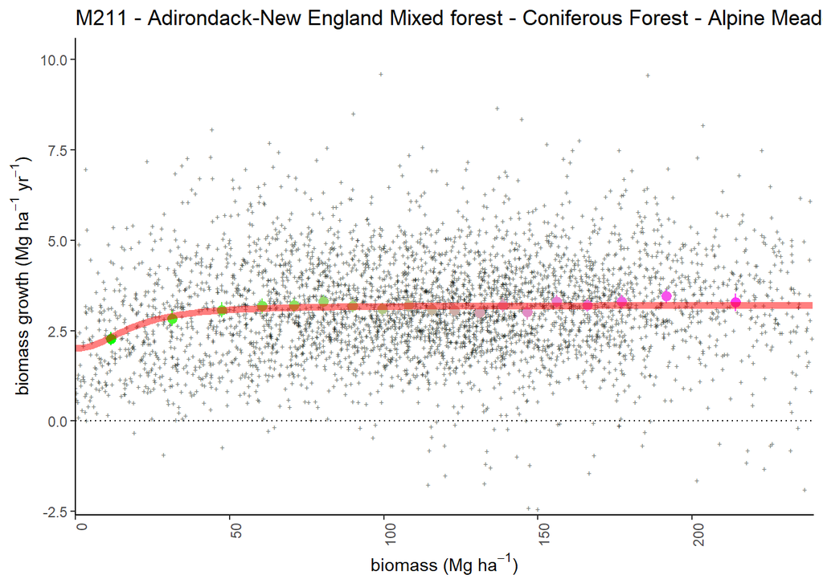

## plotting 2

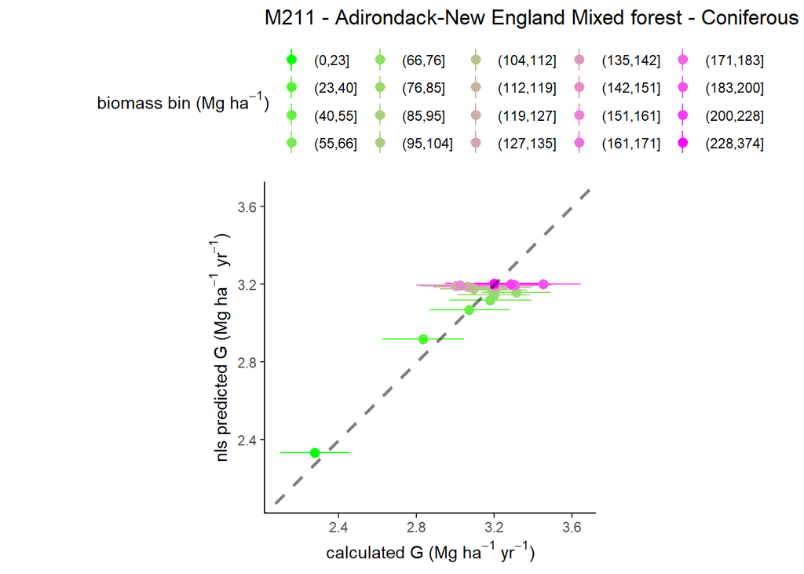

# M221 - Eastern Broadleaf Forest

## model selection 1

```
## Analysis of Variance Table
##
## Model 1: G_obs_TreeInc_MgHaYr ~ (1 + (MEASTIME_avg - 1990) * ge/100) * A * B_plt_t1_MgHa/(k + B_plt_t1_MgHa)
## Model 2: G_obs_TreeInc_MgHaYr ~ (1 + (MEASTIME_avg - 1990) * ge/100) * (1 + phi * DeltaPDSI) * A * B_plt_t1_MgHa/(k + B_plt_t1_MgHa)
## Model 3: G_obs_TreeInc_MgHaYr ~ (1 + (MEASTIME_avg - 1990) * ge/100) * (1 + phi * DeltaPDSI) * (1 - alpha * B_L_prop) * A * B_plt_t1_MgHa/(k + B_plt_t1_MgHa)
##   Res.Df Res.Sum Sq Df Sum Sq F value    Pr(>F)
## 1   4547     6530.3
## 2   4546     6524.4  1  5.903  4.1129   0.04262 *
## 3   4545     6470.1  1 54.289 38.1357 7.175e-10 ***
## ---
## Signif. codes:  0 '***' 0.001 '**' 0.01 '*' 0.05 '.' 0.1 ' ' 1
##   model      AIC
## 1     1 20591.06
## 2     2 20588.94
## 3     3 20552.93
```

```
##
## Formula: G_obs_TreeInc_MgHaYr ~ (1 + (MEASTIME_avg - 1990) * ge/100) *
##     (1 + phi * DeltaPDSI) * (1 - alpha * B_L_prop) * A * B_plt_t1_MgHa/(k +
##     B_plt_t1_MgHa)
##
## Parameters:
##        Estimate Std. Error t value Pr(>|t|)
## ge    -0.820706   0.132170  -6.209 5.79e-10 ***
## phi   -0.014652   0.007665  -1.911    0.056 .
## alpha  0.637499   0.099815   6.387 1.86e-10 ***
## A      5.179241   0.184143  28.126  < 2e-16 ***
## k     11.882076   2.027212   5.861 4.92e-09 ***
## ---
## Signif. codes:  0 '***' 0.001 '**' 0.01 '*' 0.05 '.' 0.1 ' ' 1
##
## Residual standard error: 1.193 on 4545 degrees of freedom
##
## Number of iterations to convergence: 7
## Achieved convergence tolerance: 9.793e-06
```

### summary

- simple model: fits
- phi model: fits
- phi-alpha model: fits

## model selection 2

```
## Error in nls(get(paste("fg_", Mod.Sel1, "b", sep = "")), data = G_M221,  :
##   number of iterations exceeded maximum of 50
## Error in numericDeriv(form[[3L]], names(ind), env, central = nDcentral) :
##   Missing value or an infinity produced when evaluating the model
## Analysis of Variance Table
##
## Model 1: G_obs_TreeInc_MgHaYr ~ (1 + (MEASTIME_avg - 1990) * ge/100) * (1 + phi * DeltaPDSI) * (1 - alpha * B_L_prop) * A * B_plt_t1_MgHa/(k + B_plt_t1_MgHa)
## Model 2: G_obs_TreeInc_MgHaYr ~ (1 + (MEASTIME_avg - 1990) * ge/100) * (1 + phi * DeltaPDSI) * (1 - alpha * B_L_prop) * (p * A + ((1 - p) * A * B_plt_t1_MgHa/(k + B_plt_t1_MgHa)))
##   Res.Df Res.Sum Sq Df Sum Sq F value    Pr(>F)
## 1   4545     6470.1
## 2   4544     6413.1  1 56.977  40.371 2.307e-10 ***
## ---
## Signif. codes:  0 '***' 0.001 '**' 0.01 '*' 0.05 '.' 0.1 ' ' 1
##   model      AIC
## 1     3 20552.93
## 2    3a 20514.68
## 3    3b       NA
## 4    3c       NA
```

```
##
## Formula: G_obs_TreeInc_MgHaYr ~ (1 + (MEASTIME_avg - 1990) * ge/100) *
##     (1 + phi * DeltaPDSI) * (1 - alpha * B_L_prop) * (p * A +
##     ((1 - p) * A * B_plt_t1_MgHa/(k + B_plt_t1_MgHa)))
##
## Parameters:
##         Estimate Std. Error t value Pr(>|t|)
## ge    -9.068e-01  1.272e-01  -7.129 1.17e-12 ***
## phi   -1.129e-02  7.636e-03  -1.479    0.139
## alpha  6.031e-01  9.907e-02   6.088 1.24e-09 ***
## A      1.939e+01  2.576e+01   0.752    0.452
## k      1.822e+03  3.473e+03   0.524    0.600
## p      1.869e-01  2.411e-01   0.775    0.438
## ---
## Signif. codes:  0 '***' 0.001 '**' 0.01 '*' 0.05 '.' 0.1 ' ' 1
##
## Residual standard error: 1.188 on 4544 degrees of freedom
##
## Number of iterations to convergence: 18
## Achieved convergence tolerance: 2.212e-07
```

### summary

- add p model: fits
- add s model: does not fit
- add s+p model: does not fit

## plot residuals

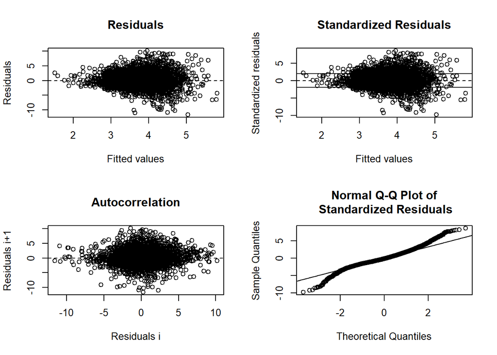

```
##
## ------
##  Shapiro-Wilk normality test
##
## data:  stdres
## W = 0.97145, p-value < 2.2e-16
##
##
## ------
```

```
##
##  Runs Test
##
## data:  as.factor(run)
## Standard Normal = -8.8926, p-value < 2.2e-16
## alternative hypothesis: two.sided
```

## predict and plot

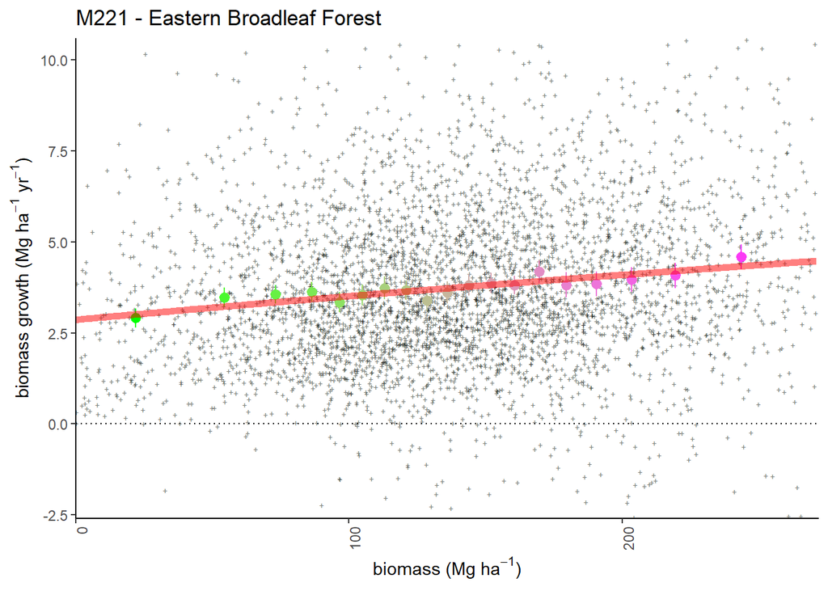

## plotting 2

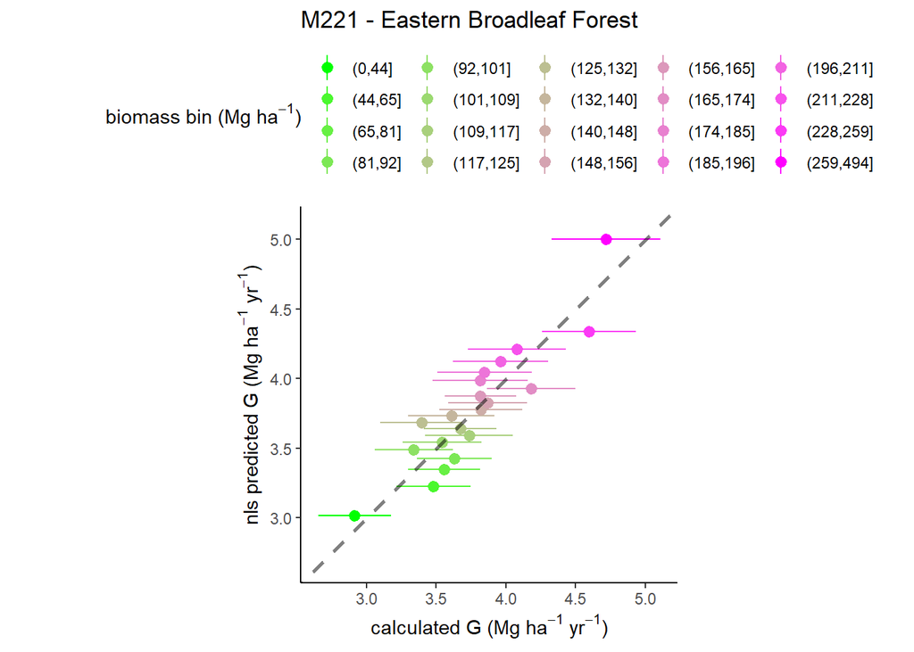

# M223 - Ozark Broadleaf Forest Meadow

## model selection 1

```
## Analysis of Variance Table
##
## Model 1: G_obs_TreeInc_MgHaYr ~ (1 + (MEASTIME_avg - 1990) * ge/100) * A * B_plt_t1_MgHa/(k + B_plt_t1_MgHa)
## Model 2: G_obs_TreeInc_MgHaYr ~ (1 + (MEASTIME_avg - 1990) * ge/100) * (1 + phi * DeltaPDSI) * A * B_plt_t1_MgHa/(k + B_plt_t1_MgHa)
## Model 3: G_obs_TreeInc_MgHaYr ~ (1 + (MEASTIME_avg - 1990) * ge/100) * (1 + phi * DeltaPDSI) * (1 - alpha * B_L_prop) * A * B_plt_t1_MgHa/(k + B_plt_t1_MgHa)
##   Res.Df Res.Sum Sq Df Sum Sq F value  Pr(>F)
## 1    519     691.31
## 2    518     691.19  1 0.1129  0.0846 0.77130
## 3    517     687.04  1 4.1511  3.1237 0.07775 .
## ---
## Signif. codes:  0 '***' 0.001 '**' 0.01 '*' 0.05 '.' 0.1 ' ' 1
##   model      AIC
## 1     1 2127.184
## 2     2 2129.099
## 3     3 2127.955
```

```
##
## Formula: G_obs_TreeInc_MgHaYr ~ (1 + (MEASTIME_avg - 1990) * ge/100) *
##     A * B_plt_t1_MgHa/(k + B_plt_t1_MgHa)
##
## Parameters:
##    Estimate Std. Error t value Pr(>|t|)
## ge   1.9056     1.2343   1.544   0.1232
## A    2.3171     0.4978   4.655 4.13e-06 ***
## k   25.6498    12.0152   2.135   0.0332 *
## ---
## Signif. codes:  0 '***' 0.001 '**' 0.01 '*' 0.05 '.' 0.1 ' ' 1
##
## Residual standard error: 1.154 on 519 degrees of freedom
##
## Number of iterations to convergence: 10
## Achieved convergence tolerance: 4.011e-06
```

### summary

- simple model: fits
- phi model: fits
- phi-alpha model: fits

## model selection 2

```
## Error in nls(get(paste("fg_", Mod.Sel1, "b", sep = "")), data = G_M223,  :
##   number of iterations exceeded maximum of 50
## Error in nls(get(paste("fg_", Mod.Sel1, "c", sep = "")), data = G_M223,  :
##   step factor 0.000488281 reduced below 'minFactor' of 0.000976562
## Analysis of Variance Table
##
## Model 1: G_obs_TreeInc_MgHaYr ~ (1 + (MEASTIME_avg - 1990) * ge/100) * A * B_plt_t1_MgHa/(k + B_plt_t1_MgHa)
## Model 2: G_obs_TreeInc_MgHaYr ~ (1 + (MEASTIME_avg - 1990) * ge/100) * (p * A + ((1 - p) * A * B_plt_t1_MgHa/(k + B_plt_t1_MgHa)))
##   Res.Df Res.Sum Sq Df Sum Sq F value  Pr(>F)
## 1    519     691.31
## 2    518     685.16  1  6.149  4.6488 0.03153 *
## ---
## Signif. codes:  0 '***' 0.001 '**' 0.01 '*' 0.05 '.' 0.1 ' ' 1
##   model      AIC
## 1     1 2127.184
## 2    1a 2124.520
## 3    1b       NA
## 4    1c       NA
```

```
##
## Formula: G_obs_TreeInc_MgHaYr ~ (1 + (MEASTIME_avg - 1990) * ge/100) *
##     (p * A + ((1 - p) * A * B_plt_t1_MgHa/(k + B_plt_t1_MgHa)))
##
## Parameters:
##     Estimate Std. Error t value Pr(>|t|)
## ge 2.006e+00  1.265e+00   1.585    0.114
## A  1.118e+01  6.748e+01   0.166    0.868
## k  1.700e+03  1.302e+04   0.131    0.896
## p  1.080e-01  6.297e-01   0.171    0.864
##
## Residual standard error: 1.15 on 518 degrees of freedom
##
## Number of iterations to convergence: 24
## Achieved convergence tolerance: 3.616e-06
```

### summary

- add p model: fits
- add s model: does not fit
- add s+p model: does not fit

## plot residuals

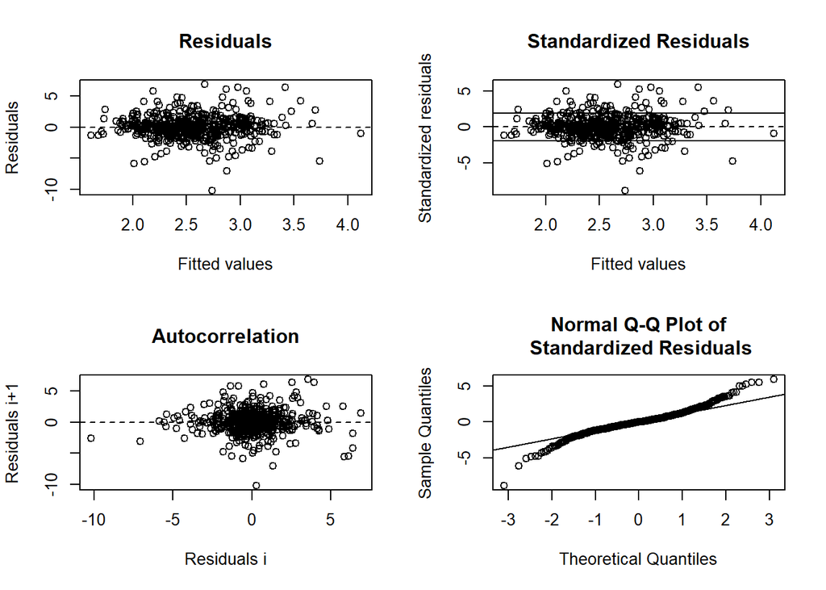

```
##
## ------
##  Shapiro-Wilk normality test
##
## data:  stdres
## W = 0.95199, p-value = 5.465e-12
##
##
## ------
```

```
##
##  Runs Test
##
## data:  as.factor(run)
## Standard Normal = -0.96255, p-value = 0.3358
## alternative hypothesis: two.sided
```

## predict and plot

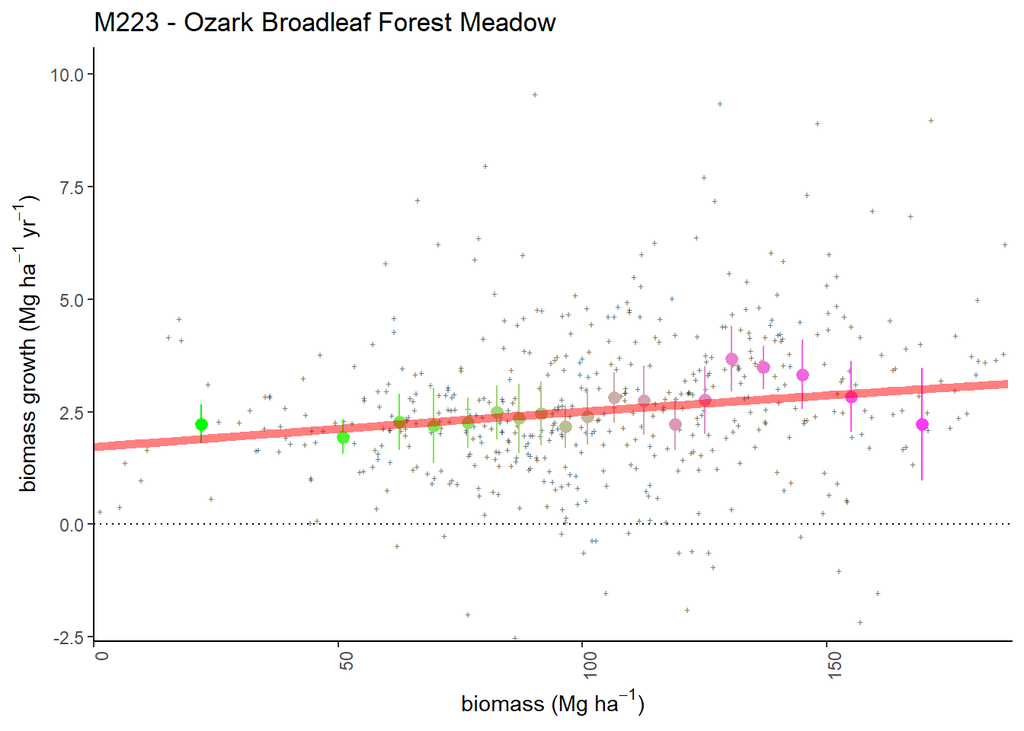

## plotting 2

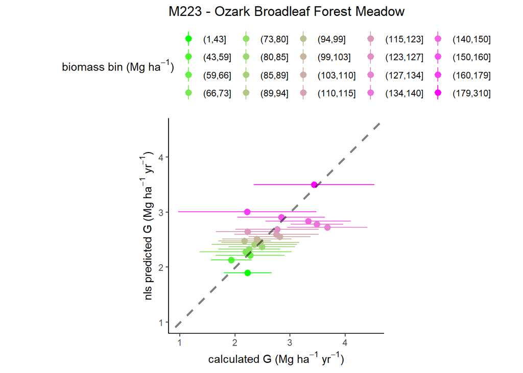

# M231 - Ouachita Mixed Forest

## model selection 1

```
## Analysis of Variance Table
##
## Model 1: G_obs_TreeInc_MgHaYr ~ (1 + (MEASTIME_avg - 1990) * ge/100) * A * B_plt_t1_MgHa/(k + B_plt_t1_MgHa)
## Model 2: G_obs_TreeInc_MgHaYr ~ (1 + (MEASTIME_avg - 1990) * ge/100) * (1 + phi * DeltaPDSI) * A * B_plt_t1_MgHa/(k + B_plt_t1_MgHa)
## Model 3: G_obs_TreeInc_MgHaYr ~ (1 + (MEASTIME_avg - 1990) * ge/100) * (1 + phi * DeltaPDSI) * (1 - alpha * B_L_prop) * A * B_plt_t1_MgHa/(k + B_plt_t1_MgHa)
##   Res.Df Res.Sum Sq Df Sum Sq F value   Pr(>F)
## 1    579     674.41
## 2    578     665.63  1 8.7802  7.6243 0.005942 **
## 3    577     661.67  1 3.9579  3.4515 0.063705 .
## ---
## Signif. codes:  0 '***' 0.001 '**' 0.01 '*' 0.05 '.' 0.1 ' ' 1
##   model      AIC
## 1     1 2313.010
## 2     2 2307.384
## 3     3 2305.913
```

```
##
## Formula: G_obs_TreeInc_MgHaYr ~ (1 + (MEASTIME_avg - 1990) * ge/100) *
##     (1 + phi * DeltaPDSI) * (1 - alpha * B_L_prop) * A * B_plt_t1_MgHa/(k +
##     B_plt_t1_MgHa)
##
## Parameters:
##       Estimate Std. Error t value Pr(>|t|)
## ge     1.44262    1.31766   1.095 0.274044
## phi    0.06590    0.03093   2.130 0.033555 *
## alpha  0.70197    0.36185   1.940 0.052870 .
## A      2.91561    0.66421   4.390 1.35e-05 ***
## k     33.41839    9.36440   3.569 0.000389 ***
## ---
## Signif. codes:  0 '***' 0.001 '**' 0.01 '*' 0.05 '.' 0.1 ' ' 1
##
## Residual standard error: 1.071 on 577 degrees of freedom
##
## Number of iterations to convergence: 13
## Achieved convergence tolerance: 6.488e-06
##   (2 observations deleted due to missingness)
```

### summary

- simple model: fits
- phi model: fits
- phi-alpha model: fits

## model selection 2

```
## Error in nls(get(paste("fg_", Mod.Sel1, "a", sep = "")), data = G_M231,  :
##   number of iterations exceeded maximum of 50
## Error in nls(get(paste("fg_", Mod.Sel1, "b", sep = "")), data = G_M231,  :
##   singular gradient
## Error in numericDeriv(form[[3L]], names(ind), env, central = nDcentral) :
##   Missing value or an infinity produced when evaluating the model
##   model      AIC
## 1     3 2305.913
## 2    3a       NA
## 3    3b       NA
## 4    3c       NA
```

```
##
## Formula: G_obs_TreeInc_MgHaYr ~ (1 + (MEASTIME_avg - 1990) * ge/100) *
##     (1 + phi * DeltaPDSI) * (1 - alpha * B_L_prop) * A * B_plt_t1_MgHa/(k +
##     B_plt_t1_MgHa)
##
## Parameters:
##       Estimate Std. Error t value Pr(>|t|)
## ge     1.44262    1.31766   1.095 0.274044
## phi    0.06590    0.03093   2.130 0.033555 *
## alpha  0.70197    0.36185   1.940 0.052870 .
## A      2.91561    0.66421   4.390 1.35e-05 ***
## k     33.41839    9.36440   3.569 0.000389 ***
## ---
## Signif. codes:  0 '***' 0.001 '**' 0.01 '*' 0.05 '.' 0.1 ' ' 1
##
## Residual standard error: 1.071 on 577 degrees of freedom
##
## Number of iterations to convergence: 13
## Achieved convergence tolerance: 6.488e-06
##   (2 observations deleted due to missingness)
```

### summary

- add p model: does not fit
- add s model: does not fit
- add s+p model: does not fit

## plot residuals

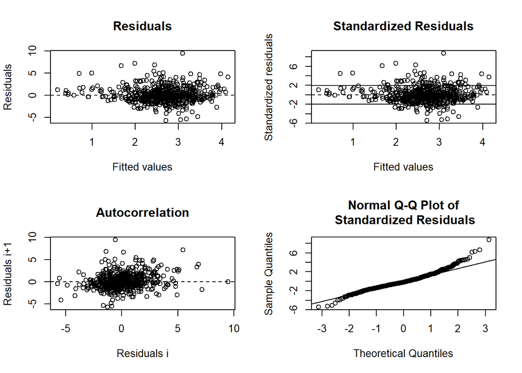

```
##
## ------
##  Shapiro-Wilk normality test
##
## data:  stdres
## W = 0.96101, p-value = 2.678e-11
##
##
## ------
```

```
##
##  Runs Test
##
## data:  as.factor(run)
## Standard Normal = -4.324, p-value = 1.532e-05
## alternative hypothesis: two.sided
```

## predict and plot

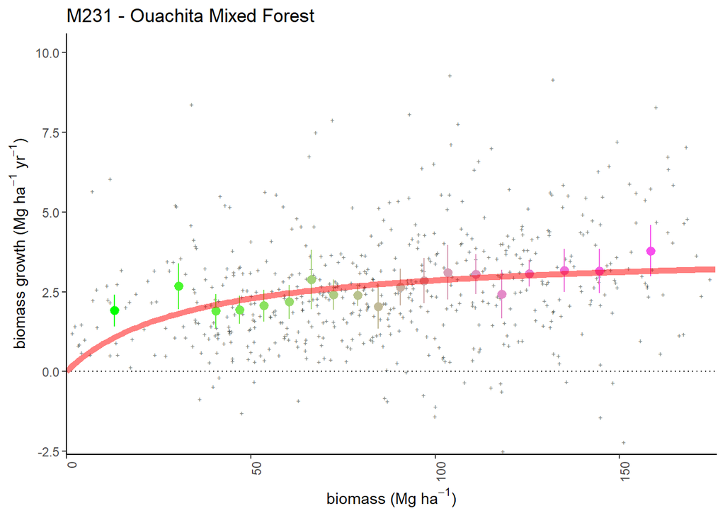

## plotting 2

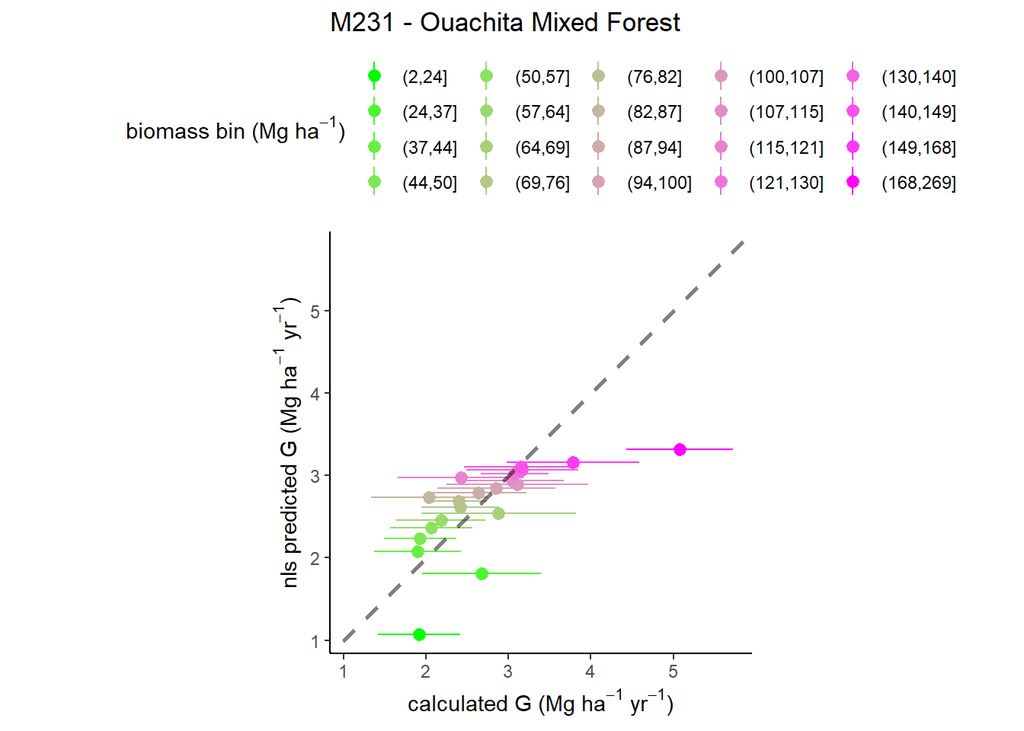

# M242 - Cascade Mixed Forest

## model selection 1

### summary

- simple model: does not fit
- phi model: does not fit
- phi-alpha model: does not fit

## model selection 2

### summary

- add p model: does not fit
- add s model: does not fit
- add s+p model: does not fit

## plot residuals

```
## [1] "cannot plot residuals"
```

## predict and plot

```
## [1] "cannot plot data with prediction"
```

## plotting 2

# M261 - Sierran Steppe - Mixed Forest - Coniferous Forest - Alpine Meadow

## model selection 1

### summary

- simple model: does not fit
- phi model: does not fit
- phi-alpha model: does not fit

## model selection 2

### summary

- add p model: does not fit
- add s model: does not fit
- add s+p model: does not fit

## plot residuals

```
## [1] "cannot plot residuals"
```

## predict and plot

```
## [1] "cannot plot data with prediction"
```

## plotting 2

# M262 - Califormia Coastal Range = Coniferous Forest - Open woodland Shrub Meadow

## model selection 1

### summary

- simple model: does not fit
- phi model: does not fit
- phi-alpha model: does not fit

## model selection 2

### summary

- add p model: does not fit
- add s model: does not fit
- add s+p model: does not fit

## plot residuals

```
## [1] "cannot plot residuals"
```

## predict and plot

```
## [1] "cannot plot data with prediction"
```

## plotting 2

# M313 - Arizona-New Mexico Mountains Semi-Desert - Open Woodland - Coniferous Forest - Alpine Meadow

## model selection 1

### summary

- simple model: does not fit
- phi model: does not fit
- phi-alpha model: does not fit

## model selection 2

### summary

- add p model: does not fit
- add s model: does not fit
- add s+p model: does not fit

## plot residuals

```
## [1] "cannot plot residuals"
```

## predict and plot

```
## [1] "cannot plot data with prediction"
```

## plotting 2

# M331 - Southern Rocky Mountain Steppe - Open Woodland - Coniferous Forest - Alpine Meadow

## model selection 1

### summary

- simple model: does not fit
- phi model: does not fit
- phi-alpha model: does not fit

## model selection 2

### summary

- add p model: does not fit
- add s model: does not fit
- add s+p model: does not fit

## plot residuals

```
## [1] "cannot plot residuals"
```

## predict and plot

```
## [1] "cannot plot data with prediction"
```

## plotting 2

# M332 - Middle Rocky Mountain Steppe - Coniferous Forest - Alpine Meadow

## model selection 1

### summary

- simple model: does not fit
- phi model: does not fit
- phi-alpha model: does not fit

## model selection 2

### summary

- add p model: does not fit
- add s model: does not fit
- add s+p model: does not fit

## plot residuals

```
## [1] "cannot plot residuals"
```

## predict and plot

```
## [1] "cannot plot data with prediction"
```

## plotting 2

# M333 - Northern Rocky Mountain Steppe - Coniferous Forest - Alpine Meadow

## model selection 1

### summary

- simple model: does not fit
- phi model: does not fit
- phi-alpha model: does not fit

## model selection 2

### summary

- add p model: does not fit
- add s model: does not fit
- add s+p model: does not fit

## plot residuals

```
## [1] "cannot plot residuals"
```

## predict and plot

```
## [1] "cannot plot data with prediction"
```

## plotting 2

# M334 - Black Hills Coniferous Forest

## model selection 1

```
## Analysis of Variance Table
##
## Model 1: G_obs_TreeInc_MgHaYr ~ (1 + (MEASTIME_avg - 1990) * ge/100) * A * B_plt_t1_MgHa/(k + B_plt_t1_MgHa)
## Model 2: G_obs_TreeInc_MgHaYr ~ (1 + (MEASTIME_avg - 1990) * ge/100) * (1 + phi * DeltaPDSI) * A * B_plt_t1_MgHa/(k + B_plt_t1_MgHa)
## Model 3: G_obs_TreeInc_MgHaYr ~ (1 + (MEASTIME_avg - 1990) * ge/100) * (1 + phi * DeltaPDSI) * (1 - alpha * B_L_prop) * A * B_plt_t1_MgHa/(k + B_plt_t1_MgHa)
##   Res.Df Res.Sum Sq Df Sum Sq F value   Pr(>F)
## 1    225     178.16
## 2    224     177.93  1 0.2311  0.2910 0.590134
## 3    223     170.52  1 7.4116  9.6927 0.002092 **
## ---
## Signif. codes:  0 '***' 0.001 '**' 0.01 '*' 0.05 '.' 0.1 ' ' 1
##   model      AIC
## 1     1 637.1159
## 2     2 638.8200
## 3     3 631.1193
```

```
##
## Formula: G_obs_TreeInc_MgHaYr ~ (1 + (MEASTIME_avg - 1990) * ge/100) *
##     (1 + phi * DeltaPDSI) * (1 - alpha * B_L_prop) * A * B_plt_t1_MgHa/(k +
##     B_plt_t1_MgHa)
##
## Parameters:
##        Estimate Std. Error t value Pr(>|t|)
## ge     0.860157   3.110892   0.276   0.7824
## phi    0.003362   0.046266   0.073   0.9421
## alpha  0.760170   0.221127   3.438   0.0007 ***
## A      1.941914   1.058631   1.834   0.0679 .
## k     33.746021  12.610721   2.676   0.0080 **
## ---
## Signif. codes:  0 '***' 0.001 '**' 0.01 '*' 0.05 '.' 0.1 ' ' 1
##
## Residual standard error: 0.8744 on 223 degrees of freedom
##
## Number of iterations to convergence: 12
## Achieved convergence tolerance: 6.745e-06
```

### summary

- simple model: fits
- phi model: fits
- phi-alpha model: fits

## model selection 2

```
## Analysis of Variance Table
##
## Model 1: G_obs_TreeInc_MgHaYr ~ (1 + (MEASTIME_avg - 1990) * ge/100) * (1 + phi * DeltaPDSI) * (1 - alpha * B_L_prop) * A * B_plt_t1_MgHa/(k + B_plt_t1_MgHa)
## Model 2: G_obs_TreeInc_MgHaYr ~ (1 + (MEASTIME_avg - 1990) * ge/100) * (1 + phi * DeltaPDSI) * (1 - alpha * B_L_prop) * (p * A + ((1 - p) * A * B_plt_t1_MgHa/(k + B_plt_t1_MgHa)))
## Model 3: G_obs_TreeInc_MgHaYr ~ (1 + (MEASTIME_avg - 1990) * ge/100) * (1 + phi * DeltaPDSI) * (1 - alpha * B_L_prop) * (A * B_plt_t1_MgHa^s/(k^s + B_plt_t1_MgHa^s))
## Model 4: G_obs_TreeInc_MgHaYr ~ (1 + (MEASTIME_avg - 1990) * ge/100) * (1 + phi * DeltaPDSI) * (1 - alpha * B_L_prop) * (p * A + ((1 - p) * A * B_plt_t1_MgHa^s/(k^s + B_plt_t1_MgHa^s)))
##   Res.Df Res.Sum Sq Df  Sum Sq F value Pr(>F)
## 1    223     170.52
## 2    222     170.49  1 0.03008  0.0392 0.8433
## 3    222     170.47  0 0.00000
## 4    221     169.43  1 1.04343  1.3610 0.2446
##   model      AIC
## 1     3 631.1193
## 2    3a 633.0791
## 3    3b 633.0578
## 4    3c 633.6580
```

```
##
## Formula: G_obs_TreeInc_MgHaYr ~ (1 + (MEASTIME_avg - 1990) * ge/100) *
##     (1 + phi * DeltaPDSI) * (1 - alpha * B_L_prop) * A * B_plt_t1_MgHa/(k +
##     B_plt_t1_MgHa)
##
## Parameters:
##        Estimate Std. Error t value Pr(>|t|)
## ge     0.860157   3.110892   0.276   0.7824
## phi    0.003362   0.046266   0.073   0.9421
## alpha  0.760170   0.221127   3.438   0.0007 ***
## A      1.941914   1.058631   1.834   0.0679 .
## k     33.746021  12.610721   2.676   0.0080 **
## ---
## Signif. codes:  0 '***' 0.001 '**' 0.01 '*' 0.05 '.' 0.1 ' ' 1
##
## Residual standard error: 0.8744 on 223 degrees of freedom
##
## Number of iterations to convergence: 12
## Achieved convergence tolerance: 6.745e-06
```

### summary

- add p model: fits
- add s model: fits
- add s+p model: fits

## plot residuals

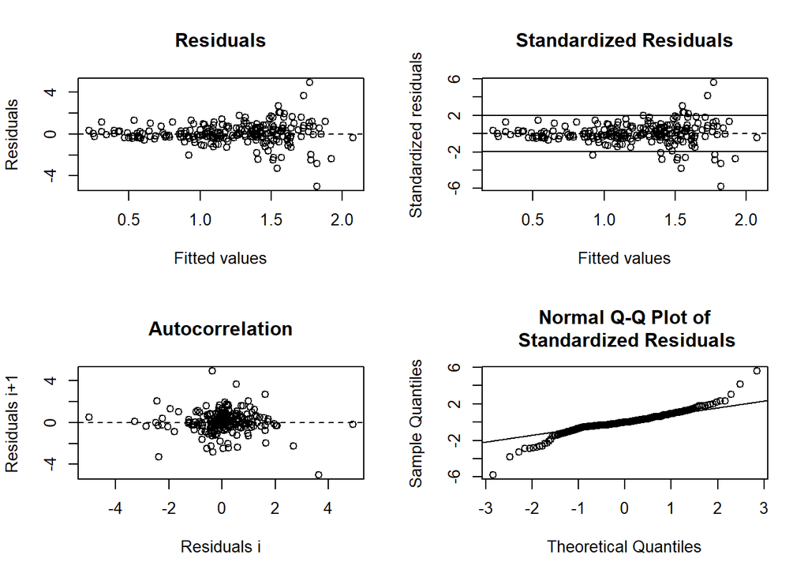

```
##
## ------
##  Shapiro-Wilk normality test
##
## data:  stdres
## W = 0.91247, p-value = 2.553e-10
##
##
## ------
```

```
##
##  Runs Test
##
## data:  as.factor(run)
## Standard Normal = -1.8421, p-value = 0.06546
## alternative hypothesis: two.sided
```

## predict and plot

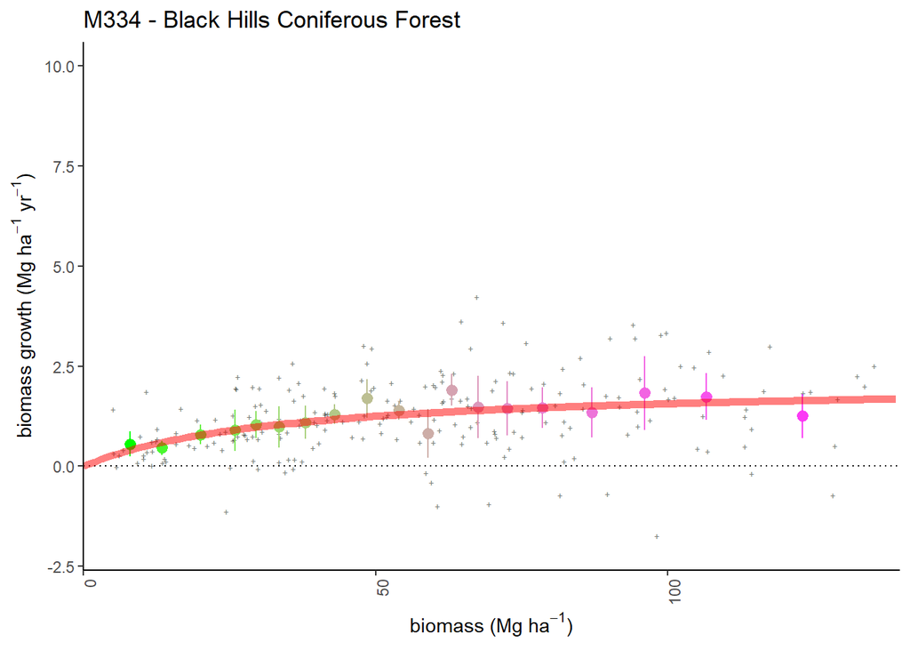

## plotting 2

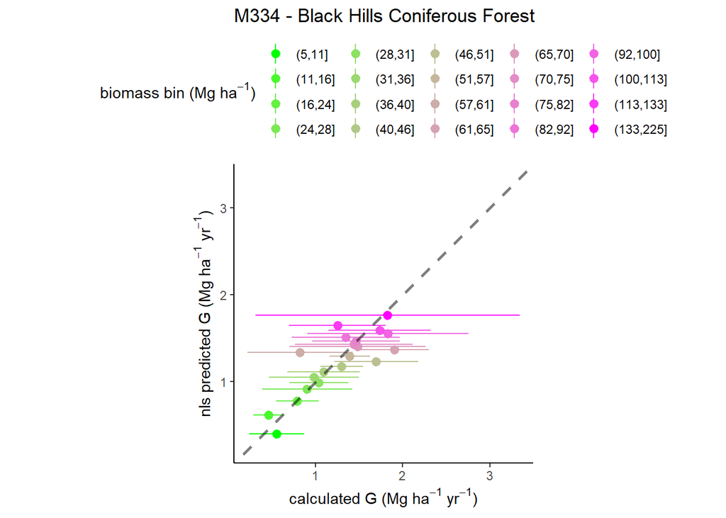

# M341 - Nevada-Utah Mountains Semi-Desert - Coniferous Forest - Alpine Meadow

## model selection 1

### summary

- simple model: does not fit
- phi model: does not fit
- phi-alpha model: does not fit

## model selection 2

### summary

- add p model: does not fit
- add s model: does not fit
- add s+p model: does not fit

## plot residuals

```
## [1] "cannot plot residuals"
```

## predict and plot

```
## [1] "cannot plot data with prediction"
```

## plotting 2

# Fitted parameters

## Best / selected models by ecoprovince

| Code | Ecoregion | Sel.Mod |
| --- | --- | --- |
| 211 | Northeastern Mixed Forest | 3a |
| 212 | Laurentian Mixed Forest | 3a |
| 221 | Eastern Broadleaf Forest | 3a |
| 222 | Midwest Broadleaf Forest | 3a |
| 223 | Central Interior Broadleaf Forest | 3 |
| 231 | Southeastern Mixed Forest | 3b |
| 232 | Outer Coastal Plain Mixed Forest | 3a |
| 234 | Lower Mississippi Riverine Forest | 3 |
| 242 | Pacific Lowland Mixed Forest | NA |
| 251 | Prairie Parkland (Temperate) | 3c |
| 255 | Prairie Parkland (Subtropical) | NA |
| 261 | California Coastal Chaparral Forest and Shrub | NA |
| 262 | California Dry Steppe | NA |
| 263 | California Coastal Steppe - Mixed Forest and Redwood Forest | NA |
| 313 | Colorado Plateau Semi-Desert | NA |
| 315 | Southwest Plateau and Plains Dry Steppe and Shrub | NA |
| 321 | Chihuahuan Semi-Desert | NA |
| 322 | American Semidesert and Desert | NA |
| 331 | Great Plains/Palouse Dry Steppe | NA |
| 332 | Great Plains Steppe | 1 |
| 341 | Intermountain Semi-Desert and Desert | NA |
| 342 | Intermountain Semi-Desert | NA |
| 411 | Everglades | NA |
| M211 | Adirondack-New England Mixed forest - Coniferous Forest - Alpine Meadow | 3c |
| M221 | Central Appalachian Broadleaf Forest - Coniferous Forest - Meadow | 3a |
| M223 | Ozark Broadleaf Forest Meadow | 1a |
| M231 | Ouachita Mixed Forest | 3 |
| M242 | Cascade Mixed Forest | NA |
| M261 | Sierran Steppe - Mixed Forest - Coniferous Forest - Alpine Meadow | NA |
| M262 | California Coastal Range Coniferous Forest - Open Woodland - Shrub - Meadow | NA |
| M313 | Arizona-New Mexico Mountains Semi-Desert - Open Woodland - Coniferous Forest - Alpine Meadow | NA |
| M331 | Southern Rocky Mountain Steppe - Open Woodland - Coniferous Forest - Alpine Meadow | NA |
| M332 | Middle Rocky Mountain Steppe - Coniferous Forest - Alpine Meadow | NA |
| M333 | Northern Rocky Mountain Steppe - Coniferous Forest - Alpine Meadow | NA |
| M334 | Black Hills Coniferous Forest | 3 |
| M341 | Nevada-Utah Mountains Semi-Desert - Coniferous Forest - Alpine Meadow | NA |

## table by ecoprovince

| Code | Ecoregion | region | n.obs | n.plots | ge | ge.2.5 | ge.97.5 | phi | phi.2.5 | phi.97.5 | alpha | alpha.2.5 | alpha.97.5 | A | A.2.5 | A.97.5 | k | k.2.5 | k.97.5 |
| --- | --- | --- | --- | --- | --- | --- | --- | --- | --- | --- | --- | --- | --- | --- | --- | --- | --- | --- | --- |
| 211 | Northeastern Mixed Forest | east | 3714 | 1857 | 0.0390381 | -0.3115995 | 0.3896757 | 0.0048689 | -0.0062569 | 0.0159948 | 0.5170667 | 0.3457026 | 0.6884308 | 3.701535 | 3.4259361 | 3.977134 | 13.465734 | 8.288301 | 18.643167 |
| 212 | Laurentian Mixed Forest | east | 9658 | 4829 | 0.3231528 | 0.0422766 | 0.6040291 | 0.0241147 | 0.0161019 | 0.0321275 | 0.5567597 | 0.4599646 | 0.6535548 | 3.322911 | 3.1169889 | 3.528834 | 32.009397 | 26.485343 | 37.533451 |
| 221 | Eastern Broadleaf Forest | east | 4386 | 2193 | -1.4430083 | -1.6410210 | -1.2449955 | -0.0005283 | -0.0123533 | 0.0112966 | 0.5285670 | 0.3802343 | 0.6768998 | 7.586607 | 6.6624453 | 8.510768 | 95.638209 | 46.053236 | 145.223182 |
| 222 | Midwest Broadleaf Forest | east | 2576 | 1288 | -0.1666823 | -0.6396564 | 0.3062917 | 0.0132024 | -0.0067063 | 0.0331111 | 0.7271286 | 0.5859438 | 0.8683133 | 5.746503 | 4.9762499 | 6.516756 | 86.098906 | 58.380717 | 113.817096 |
| 223 | Central Interior Broadleaf Forest | east | 5024 | 2512 | -1.3958189 | -1.5926526 | -1.1989852 | -0.0107866 | -0.0260505 | 0.0044773 | 0.6055270 | 0.4510822 | 0.7599718 | 6.689444 | 6.2016239 | 7.177265 | 46.537457 | 38.832808 | 54.242106 |
| 231 | Southeastern Mixed Forest | east | 5952 | 2976 | -0.4272579 | -0.6542925 | -0.2002232 | -0.0079539 | -0.0194190 | 0.0035113 | 0.8184707 | 0.6848087 | 0.9521327 | 6.754254 | 5.8551938 | 7.653313 | 3.896714 | 1.906176 | 5.887252 |
| 232 | Outer Coastal Plain Mixed Forest | east | 6120 | 3060 | -0.3351172 | -0.6207185 | -0.0495159 | -0.0148232 | -0.0273013 | -0.0023451 | 0.7737999 | 0.6514474 | 0.8961524 | 6.120930 | 5.6466754 | 6.595185 | 31.226419 | 21.461172 | 40.991666 |
| 234 | Lower Mississippi Riverine Forest | east | 640 | 320 | 0.0232856 | -1.5217328 | 1.5683040 | -0.0004531 | -0.0574484 | 0.0565423 | 0.8796222 | 0.5365372 | 1.2227072 | 4.948638 | 3.3303361 | 6.566939 | 14.041854 | 5.127145 | 22.956564 |
| 242 | Pacific Lowland Mixed Forest | pacific | 0 | 0 | NA | NA | NA | NA | NA | NA | NA | NA | NA | NA | NA | NA | NA | NA | NA |
| 251 | Prairie Parkland (Temperate) | east | 1112 | 556 | -0.8677948 | -1.4369709 | -0.2986187 | 0.0151356 | -0.0107528 | 0.0410241 | 0.3004780 | 0.0377896 | 0.5631665 | 5.108750 | 2.3871162 | 7.830385 | 133.154677 | 14.074076 | 252.235278 |
| 255 | Prairie Parkland (Subtropical) | pacific | 382 | 191 | NA | NA | NA | NA | NA | NA | NA | NA | NA | NA | NA | NA | NA | NA | NA |
| 261 | California Coastal Chaparral Forest and Shrub | pacific | 0 | 0 | NA | NA | NA | NA | NA | NA | NA | NA | NA | NA | NA | NA | NA | NA | NA |
| 262 | California Dry Steppe | pacific | 0 | 0 | NA | NA | NA | NA | NA | NA | NA | NA | NA | NA | NA | NA | NA | NA | NA |
| 263 | California Coastal Steppe - Mixed Forest and Redwood Forest | pacific | 0 | 0 | NA | NA | NA | NA | NA | NA | NA | NA | NA | NA | NA | NA | NA | NA | NA |
| 313 | Colorado Plateau Semi-Desert | interior west | 0 | 0 | NA | NA | NA | NA | NA | NA | NA | NA | NA | NA | NA | NA | NA | NA | NA |
| 315 | Southwest Plateau and Plains Dry Steppe and Shrub | interior west | 0 | 0 | NA | NA | NA | NA | NA | NA | NA | NA | NA | NA | NA | NA | NA | NA | NA |
| 321 | Chihuahuan Semi-Desert | interior west | 0 | 0 | NA | NA | NA | NA | NA | NA | NA | NA | NA | NA | NA | NA | NA | NA | NA |
| 322 | American Semidesert and Desert | interior west | 0 | 0 | NA | NA | NA | NA | NA | NA | NA | NA | NA | NA | NA | NA | NA | NA | NA |
| 331 | Great Plains/Palouse Dry Steppe | interior west | 100 | 50 | NA | NA | NA | NA | NA | NA | NA | NA | NA | NA | NA | NA | NA | NA | NA |
| 332 | Great Plains Steppe | interior west | 124 | 62 | -0.0349867 | -3.1992507 | 3.1292773 | NA | NA | NA | NA | NA | NA | 4.602826 | 0.5932325 | 8.612420 | 107.735320 | 8.134212 | 207.336428 |
| 341 | Intermountain Semi-Desert and Desert | interior west | 0 | 0 | NA | NA | NA | NA | NA | NA | NA | NA | NA | NA | NA | NA | NA | NA | NA |
| 342 | Intermountain Semi-Desert | interior west | 2 | 1 | NA | NA | NA | NA | NA | NA | NA | NA | NA | NA | NA | NA | NA | NA | NA |
| 411 | Everglades | east | 60 | 30 | NA | NA | NA | NA | NA | NA | NA | NA | NA | NA | NA | NA | NA | NA | NA |
| M211 | Adirondack-New England Mixed forest - Coniferous Forest - Alpine Meadow | east | 3948 | 1974 | 0.9349153 | 0.4630653 | 1.4067653 | 0.0081173 | -0.0019454 | 0.0181800 | 0.5641821 | 0.4046153 | 0.7237488 | 2.769373 | 2.5258747 | 3.012872 | 19.057445 | 10.216382 | 27.898509 |
| M221 | Central Appalachian Broadleaf Forest - Coniferous Forest - Meadow | east | 4550 | 2275 | -0.9067528 | -1.1561000 | -0.6574056 | -0.0112902 | -0.0262596 | 0.0036791 | 0.6031175 | 0.4088920 | 0.7973430 | 19.386415 | -31.1242261 | 69.897057 | 1821.664438 | -4987.476855 | 8630.805732 |
| M223 | Ozark Broadleaf Forest Meadow | east | 522 | 261 | 2.0055455 | -0.4802985 | 4.4913895 | NA | NA | NA | NA | NA | NA | 11.183406 | -121.3824839 | 143.749296 | 1699.906716 | -23879.899372 | 27279.712803 |
| M231 | Ouachita Mixed Forest | east | 584 | 292 | 1.4426216 | -1.1453665 | 4.0306098 | 0.0659025 | 0.0051468 | 0.1266582 | 0.7019679 | -0.0087261 | 1.4126618 | 2.915608 | 1.6110423 | 4.220173 | 33.418388 | 15.025926 | 51.810850 |
| M242 | Cascade Mixed Forest | pacific | 6 | 3 | NA | NA | NA | NA | NA | NA | NA | NA | NA | NA | NA | NA | NA | NA | NA |
| M261 | Sierran Steppe - Mixed Forest - Coniferous Forest - Alpine Meadow | pacific | 0 | 0 | NA | NA | NA | NA | NA | NA | NA | NA | NA | NA | NA | NA | NA | NA | NA |
| M262 | California Coastal Range Coniferous Forest - Open Woodland - Shrub - Meadow | interior west | 0 | 0 | NA | NA | NA | NA | NA | NA | NA | NA | NA | NA | NA | NA | NA | NA | NA |
| M313 | Arizona-New Mexico Mountains Semi-Desert - Open Woodland - Coniferous Forest - Alpine Meadow | interior west | 0 | 0 | NA | NA | NA | NA | NA | NA | NA | NA | NA | NA | NA | NA | NA | NA | NA |
| M331 | Southern Rocky Mountain Steppe - Open Woodland - Coniferous Forest - Alpine Meadow | interior west | 0 | 0 | NA | NA | NA | NA | NA | NA | NA | NA | NA | NA | NA | NA | NA | NA | NA |
| M332 | Middle Rocky Mountain Steppe - Coniferous Forest - Alpine Meadow | interior west | 2 | 1 | NA | NA | NA | NA | NA | NA | NA | NA | NA | NA | NA | NA | NA | NA | NA |
| M333 | Northern Rocky Mountain Steppe - Coniferous Forest - Alpine Meadow | interior west | 0 | 0 | NA | NA | NA | NA | NA | NA | NA | NA | NA | NA | NA | NA | NA | NA | NA |
| M334 | Black Hills Coniferous Forest | interior west | 228 | 114 | 0.8601570 | -5.2703502 | 6.9906643 | 0.0033624 | -0.0878120 | 0.0945367 | 0.7601699 | 0.3244034 | 1.1959364 | 1.941914 | -0.1442863 | 4.028114 | 33.746021 | 8.894591 | 58.597451 |
| M341 | Nevada-Utah Mountains Semi-Desert - Coniferous Forest - Alpine Meadow | interior west | 0 | 0 | NA | NA | NA | NA | NA | NA | NA | NA | NA | NA | NA | NA | NA | NA | NA |

## plot ge

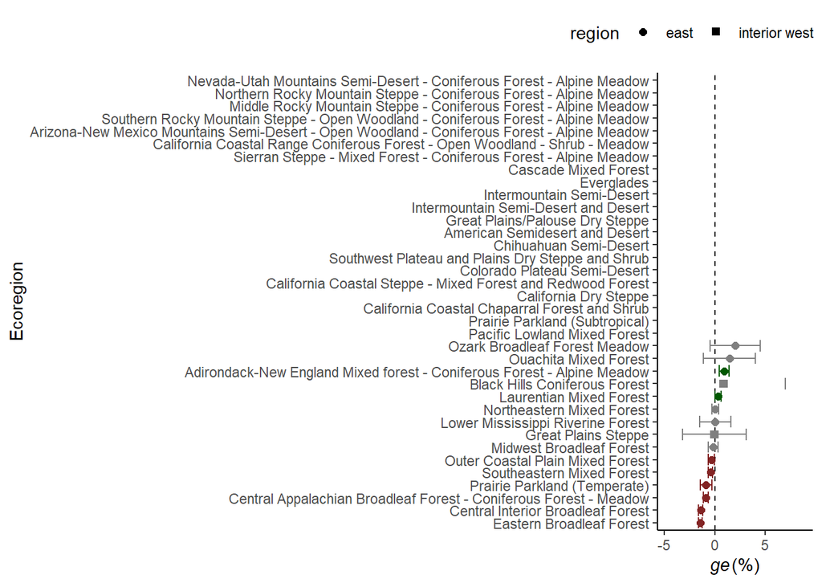

### map

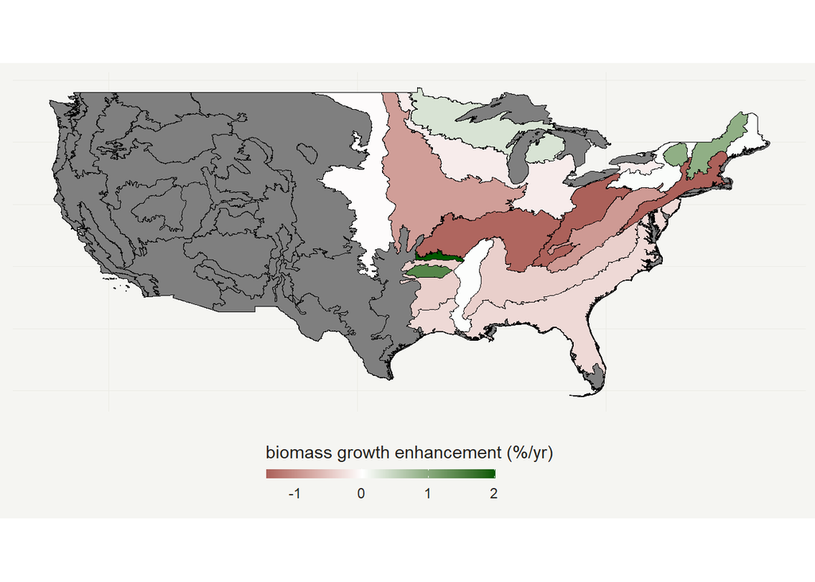

### map2

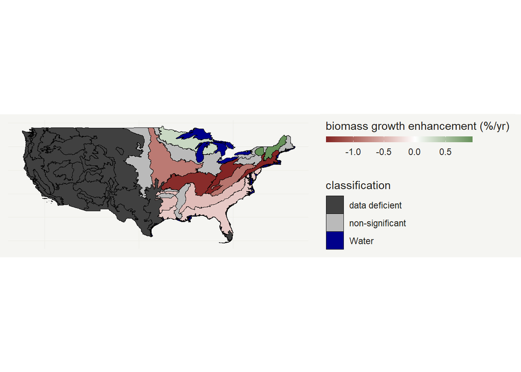

## plot phi (effect of DeltaPDSI)

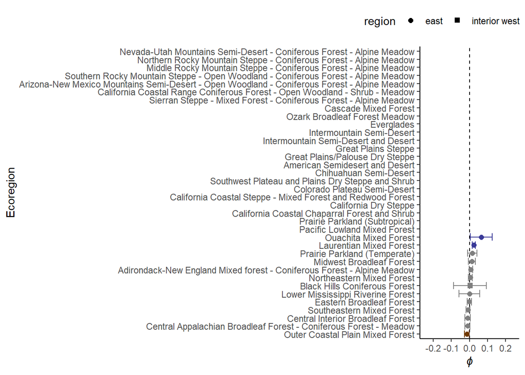

## plot alpha (biomass growth compensation effect)

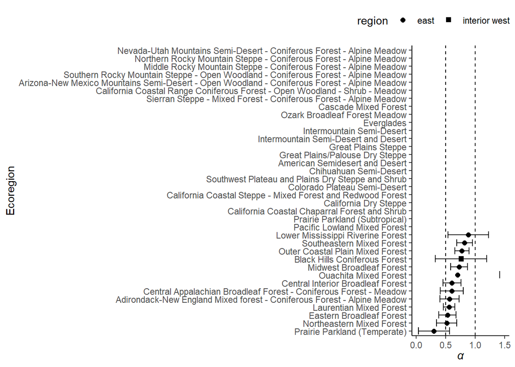

## plot A (asymptote of forest biomass growth in Mg/ha/yr)

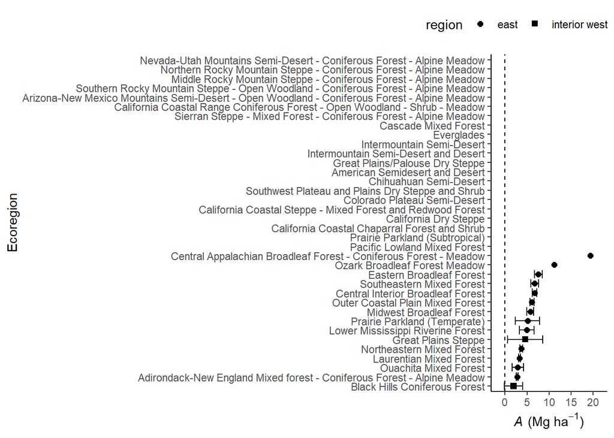

## plot k (stand biomass at half biomss G in Mg/ha)

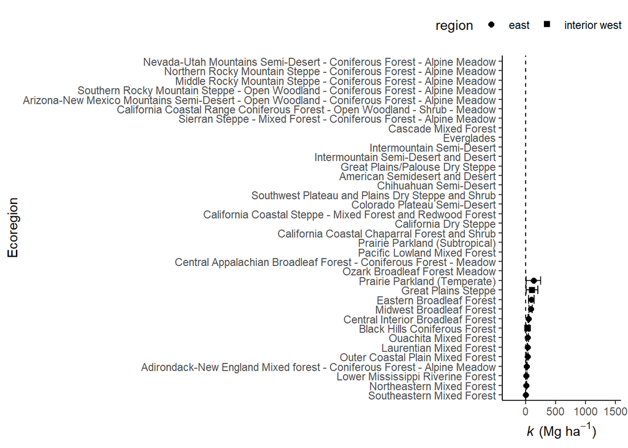

# Caclulations - weighted averages

## ge (stand biomass growth enhancement factor in % 2000-2021)

```
##          region weighted.ge
## 1     entire US  -0.2898483
## 2       pacific   0.0000000
## 3          east  -0.2987827
## 4 interior west   0.4205646
```

## phi (effect of DeltaPDSI)

```
##          region weighted.phi
## 1     entire US  0.002553731
## 2       pacific  0.000000000
## 3          east  0.002582162
## 4 interior west  0.001681189
```

## alpha (biomass growth compensation effect)

```
##          region weighted.alpha
## 1     entire US      0.6156217
## 2       pacific      0.0000000
## 3          east      0.6227106
## 4 interior west      0.3800850
```

## A (asymptote of forest biomass growth in Mg/ha/yr)

```
##          region weighted.A
## 1     entire US   6.474762
## 2       pacific   0.000000
## 3          east   6.565889
## 4 interior west   2.222603
```

## K (stand biomass at half biomss G in Mg/ha)

```
##          region weighted.k
## 1     entire US  219.30588
## 2       pacific    0.00000
## 3          east  222.66421
## 4 interior west   46.16946
```

# Calculations - weighted averages subsetted to 15 ecoprovinces

- ecoprovince codes: 211, 212, 221, 223, 231, 232, 234, 251, M211, M221, M223, M231, M242, M261, M332

## ge

```
##          region weighted.ge
## 1     entire US  -0.3064816
## 2       pacific   0.0000000
## 3          east  -0.3065346
## 4 interior west   0.0000000
```

## phi

```
##          region weighted.phi
## 1     entire US  0.001993138
## 2       pacific  0.000000000
## 3          east  0.001993483
## 4 interior west  0.000000000
```

## alpha

```
##          region weighted.alpha
## 1     entire US      0.6175914
## 2       pacific      0.0000000
## 3          east      0.6176984
## 4 interior west      0.0000000
```